# TidyTuesday 2025-03-11 - Pixar films

Vikár Míra

# Load packages

```r
# Importing the Pixar dataset directly from GitHub

pixar_films <- readr::read_csv(
  "https://raw.githubusercontent.com/rfordatascience/tidytuesday/main/data/2025/2025-03-11/pixar_films.csv"
)

public_response <- readr::read_csv(
  "https://raw.githubusercontent.com/rfordatascience/tidytuesday/main/data/2025/2025-03-11/public_response.csv"
)
```

# Pixar dataset head and glimpse

```r
head(pixar_films)
```

```
## # A tibble: 6 × 5
##   number film            release_date run_time film_rating
##    <dbl> <chr>           <date>          <dbl> <chr>
## 1      1 Toy Story       1995-11-22         81 G
## 2      2 A Bug's Life    1998-11-25         95 G
## 3      3 Toy Story 2     1999-11-24         92 G
## 4      4 Monsters, Inc.  2001-11-02         92 G
## 5      5 Finding Nemo    2003-05-30        100 G
## 6      6 The Incredibles 2004-11-05        115 PG
```

```r
head(public_response)
```

```
## # A tibble: 6 × 5
##   film            rotten_tomatoes metacritic cinema_score critics_choice
##   <chr>                     <dbl>      <dbl> <chr>                 <dbl>
## 1 Toy Story                   100         95 A                        NA
## 2 A Bug's Life                 92         77 A                        NA
## 3 Toy Story 2                 100         88 A+                      100
## 4 Monsters, Inc.               96         79 A+                       92
## 5 Finding Nemo                 99         90 A+                       97
## 6 The Incredibles              97         90 A+                       88
```

```r
knitr::kable(head(pixar_films))
```

| number | film | release_date | run_time | film_rating |
| --- | --- | --- | --- | --- |
| 1 | Toy Story | 1995-11-22 | 81 | G |
| 2 | A Bug’s Life | 1998-11-25 | 95 | G |
| 3 | Toy Story 2 | 1999-11-24 | 92 | G |
| 4 | Monsters, Inc. | 2001-11-02 | 92 | G |
| 5 | Finding Nemo | 2003-05-30 | 100 | G |
| 6 | The Incredibles | 2004-11-05 | 115 | PG |

```r
knitr::kable(head(public_response))
```

| film | rotten_tomatoes | metacritic | cinema_score | critics_choice |
| --- | --- | --- | --- | --- |
| Toy Story | 100 | 95 | A | NA |
| A Bug’s Life | 92 | 77 | A | NA |
| Toy Story 2 | 100 | 88 | A+ | 100 |
| Monsters, Inc. | 96 | 79 | A+ | 92 |
| Finding Nemo | 99 | 90 | A+ | 97 |
| The Incredibles | 97 | 90 | A+ | 88 |

```r
glimpse(pixar_films)
```

```
## Rows: 27
## Columns: 5
## $ number       <dbl> 1, 2, 3, 4, 5, 6, 7, 8, 9, 10, 11, 12, 13, 14, 15, 16, 17…
## $ film         <chr> "Toy Story", "A Bug's Life", "Toy Story 2", "Monsters, In…
## $ release_date <date> 1995-11-22, 1998-11-25, 1999-11-24, 2001-11-02, 2003-05-…
## $ run_time     <dbl> 81, 95, 92, 92, 100, 115, 117, 111, 98, 96, 103, 106, 93,…
## $ film_rating  <chr> "G", "G", "G", "G", "G", "PG", "G", "G", "G", "PG", "G", …
```

```r
glimpse(public_response)
```

```
## Rows: 24
## Columns: 5
## $ film            <chr> "Toy Story", "A Bug's Life", "Toy Story 2", "Monsters,…
## $ rotten_tomatoes <dbl> 100, 92, 100, 96, 99, 97, 74, 96, 95, 98, 98, 40, 78, …
## $ metacritic      <dbl> 95, 77, 88, 79, 90, 90, 73, 96, 95, 88, 92, 57, 69, 65…
## $ cinema_score    <chr> "A", "A", "A+", "A+", "A+", "A+", "A", "A", "A", "A+",…
## $ critics_choice  <dbl> NA, NA, 100, 92, 97, 88, 89, 91, 90, 95, 97, 67, 81, 7…
```

## 1. Data cleaning

#Examining variable types and missing data

```r
glimpse(pixar_films)
```

```
## Rows: 27
## Columns: 5
## $ number       <dbl> 1, 2, 3, 4, 5, 6, 7, 8, 9, 10, 11, 12, 13, 14, 15, 16, 17…
## $ film         <chr> "Toy Story", "A Bug's Life", "Toy Story 2", "Monsters, In…
## $ release_date <date> 1995-11-22, 1998-11-25, 1999-11-24, 2001-11-02, 2003-05-…
## $ run_time     <dbl> 81, 95, 92, 92, 100, 115, 117, 111, 98, 96, 103, 106, 93,…
## $ film_rating  <chr> "G", "G", "G", "G", "G", "PG", "G", "G", "G", "PG", "G", …
```

```r
summary(pixar_films)
```

```
##      number         film            release_date           run_time
##  Min.   : 1.0   Length:27          Min.   :1995-11-22   Min.   : 81.0
##  1st Qu.: 7.5   Class :character   1st Qu.:2006-12-18   1st Qu.: 95.0
##  Median :14.0   Mode  :character   Median :2013-06-21   Median :100.0
##  Mean   :14.0                      Mean   :2012-06-15   Mean   :104.8
##  3rd Qu.:20.5                      3rd Qu.:2018-12-17   3rd Qu.:106.0
##  Max.   :27.0                      Max.   :2023-06-16   Max.   :155.0
##                                                         NA's   :2
##  film_rating
##  Length:27
##  Class :character
##  Mode  :character
##
##
##
##
```

```r
glimpse(public_response)
```

```
## Rows: 24
## Columns: 5
## $ film            <chr> "Toy Story", "A Bug's Life", "Toy Story 2", "Monsters,…
## $ rotten_tomatoes <dbl> 100, 92, 100, 96, 99, 97, 74, 96, 95, 98, 98, 40, 78, …
## $ metacritic      <dbl> 95, 77, 88, 79, 90, 90, 73, 96, 95, 88, 92, 57, 69, 65…
## $ cinema_score    <chr> "A", "A", "A+", "A+", "A+", "A+", "A", "A", "A", "A+",…
## $ critics_choice  <dbl> NA, NA, 100, 92, 97, 88, 89, 91, 90, 95, 97, 67, 81, 7…
```

```r
summary(public_response)
```

```
##      film           rotten_tomatoes    metacritic    cinema_score
##  Length:24          Min.   : 40.00   Min.   :57.00   Length:24
##  Class :character   1st Qu.: 84.00   1st Qu.:71.00   Class :character
##  Mode  :character   Median : 96.00   Median :81.00   Mode  :character
##                     Mean   : 89.17   Mean   :79.96
##                     3rd Qu.: 97.50   3rd Qu.:90.00
##                     Max.   :100.00   Max.   :96.00
##                     NA's   :1        NA's   :1
##  critics_choice
##  Min.   : 66.00
##  1st Qu.: 81.00
##  Median : 89.00
##  Mean   : 87.14
##  3rd Qu.: 93.00
##  Max.   :100.00
##  NA's   :3
```

# Exemination of missing values

```r
public_response %>%
  filter(is.na(critics_choice) | is.na(rotten_tomatoes))
```

```
## # A tibble: 3 × 5
##   film         rotten_tomatoes metacritic cinema_score critics_choice
##   <chr>                  <dbl>      <dbl> <chr>                 <dbl>
## 1 Toy Story                100         95 A                        NA
## 2 A Bug's Life              92         77 A                        NA
## 3 Luca                      NA         NA <NA>                     NA
```

Data Overview and Initial Cleaning Steps Before starting the analysis, I examined the dataset to understand its structure and identify potential data quality issues. The dataset contains 24 Pixar films and includes the following variables:

film (character) – The title of the movie.

rotten_tomatoes (numeric) – Percentage score from Rotten Tomatoes.

metacritic (numeric) – Metacritic critic score (0–100).

cinema_score (character) – Audience grade (A, A+, etc.).

critics_choice (numeric) – Critics’ Choice rating (0–100).

Summary of Key Findings A first look using glimpse() and summary() revealed the following:

All variables were loaded correctly with the expected data types.

cinema_score is stored as a character variable, not numeric, because it contains letter-based grades (e.g., A, A+).

Some variables include missing values (NA):

critics_choice: 3 missing values

metacritic: 1 missing value

cinema_score: 1 missing value

I also inspected rows containing missing data. These came exclusively from the film “Luca” and two early films where Critics Choice ratings were not available.

Next Step: Data Cleaning Plan Since the dataset is small and missing values are minimal, carefully handling NAs is important.

# Handling Missing Data

Before proceeding with the exploratory data analysis (EDA), it is essential to examine the dataset for missing values. Missing data can influence summary statistics, distort visualisations, and potentially introduce bias during model building. Therefore, identifying and addressing these values is a necessary first step.

Treatment Strategy Because the missingness is low in proportion and the affected variables serve different analytical purposes, we apply the following approach:

# Convert cinema_score to an ordered factor

```r
public_response <- public_response %>%
  mutate(
    cinema_score = factor(
      cinema_score,
      levels = c("A-", "A", "A+"),
      ordered = TRUE
    )
  )
```

critics_choice: Since this is a numerical rating derived from awards evaluation, imputing a synthetic score would not be justified. These values are therefore retained as NA and will be handled appropriately during later modelling (e.g., filtering out incomplete rows or using models that support missingness).

#Checking the type of variable

```r
str(public_response$cinema_score)
```

```
##  Ord.factor w/ 3 levels "A-"<"A"<"A+": 2 2 3 3 3 3 2 2 2 3 ...
```

#Checking values and sequences

```r
levels(public_response$cinema_score)
```

```
## [1] "A-" "A"  "A+"
```

# Check missing values again

```r
public_response %>% summarise(across(everything(), ~ sum(is.na(.))))
```

```
## # A tibble: 1 × 5
##    film rotten_tomatoes metacritic cinema_score critics_choice
##   <int>           <int>      <int>        <int>          <int>
## 1     0               1          1            2              3
```

## 2. Exploratory Data Analysis (EDA)

###2.1 Examination of Rotten Tomatoes distribution

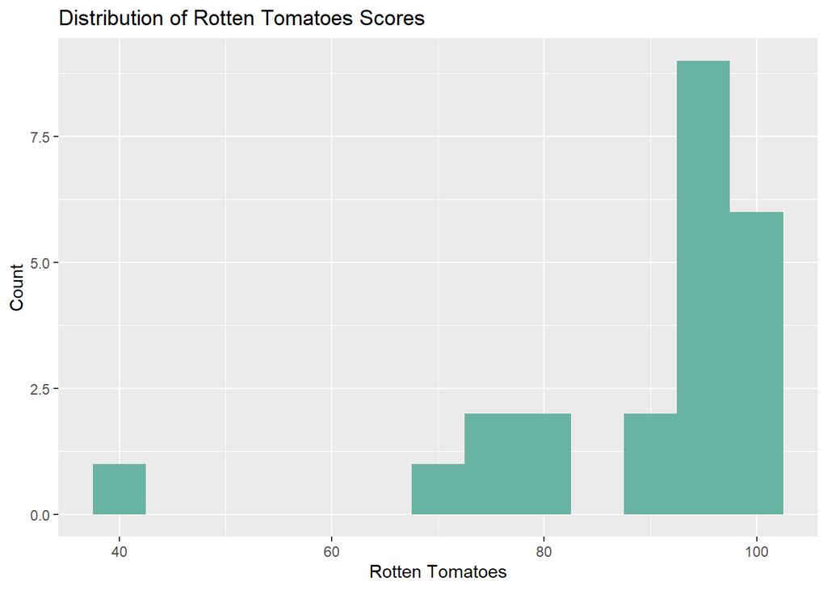

```r
public_response %>%
  ggplot(aes(x = rotten_tomatoes)) +
  geom_histogram(binwidth = 5, fill = "#69b3a2") +
  labs(title = "Distribution of Rotten Tomatoes Scores",
       x = "Rotten Tomatoes",
       y = "Count")
```

a small group around 40 points,

a medium‑sized cluster between 68 and 82 points, and

a prominent concentration between 87 and 100 points.

These clusters imply that the rating system, which ranges from 0 to 100, tends to group films into distinct quality tiers, with the majority achieving comparatively strong critical evaluations.

### 2.2 Rotten Tomatoes vs Metacritic scatterplot

Goal: to show how closely critics’ scores correlate.

[figure not shown]

```r
ggplot(public_response, aes(rotten_tomatoes, metacritic)) +
  geom_point(color = "#1f78b4", size = 3) +
  geom_smooth(method = "lm", se = FALSE, color = "red") +
  labs(title = "Relation Between Rotten Tomatoes and Metacritic Scores")
```

### 2.3 Pearson-korreláció és szignifikanciateszt

```r
cor_test_result <- cor.test(
  public_response$rotten_tomatoes,
  public_response$metacritic,
  method = "pearson"
)

cor_test_result
```

```
##
##  Pearson's product-moment correlation
##
## data:  public_response$rotten_tomatoes and public_response$metacritic
## t = 6.1679, df = 21, p-value = 4.048e-06
## alternative hypothesis: true correlation is not equal to 0
## 95 percent confidence interval:
##  0.5835946 0.9128600
## sample estimates:
##       cor
## 0.8027001
```

To quantify this relationship, a Pearson product–moment correlation was calculated. The results revealed a strong, positive, and statistically significant correlation between Rotten Tomatoes and Metacritic scores (r = 0.80, t(21) = 6.17, p < 0.001). The 95% confidence interval [0.58, 0.91] further supports the conclusion that the association is reliably above zero.

Overall, the analysis suggests that the two critic-based rating platforms provide largely consistent evaluations of film quality.